# 02_PCA

Anish

2026-04-25

# 1. Why PCA before clustering

Two distinct jobs PCA does for this project, both straight

1. **Visulisation** - project the the customers onto PC1-PC2 so we can eyeball whether segments separates in the plane of the greatest variance, colour by candidate cluster labels later, and produce the biplot.
2. **Preprocessing** - replace the seven correlated input features with 2-3 orthogonal PC scores and cluster those.

The output of this notebook is stored in PC-scores matrix (‘../data/customer_pc_scores.csv’) consumed by ‘03_clustering.Rmd’

# 2. Load the customer-level features

```r
customer <- read_csv("../data/customer_features.csv",
                     show_col_types = FALSE)
glimpse(customer)
```

```
## Rows: 4,334
## Columns: 21
## $ CustomerID         <dbl> 12346, 12347, 12348, 12349, 12350, 12352, 12353, 12…
## $ Recency            <dbl> 326, 2, 75, 19, 310, 36, 204, 232, 214, 23, 33, 2, …
## $ Frequency          <dbl> 1, 7, 4, 1, 1, 7, 1, 1, 1, 3, 1, 2, 4, 3, 1, 10, 2,…
## $ Monetary           <dbl> 77183.60, 4310.00, 1437.24, 1457.55, 294.40, 1385.7…
## $ TotalQuantity      <dbl> 74215, 2458, 2332, 630, 196, 526, 20, 530, 240, 157…
## $ UniqueProducts     <dbl> 1, 103, 21, 72, 16, 57, 4, 58, 13, 52, 131, 12, 214…
## $ AvgUnitPrice       <dbl> 1.040000, 2.644011, 0.692963, 4.237500, 1.581250, 4…
## $ FirstPurchase      <dttm> 2011-01-18 10:01:00, 2010-12-07 14:57:00, 2010-12-…
## $ LastPurchase       <dttm> 2011-01-18 10:01:00, 2011-12-07 15:52:00, 2011-09-…
## $ TenureDays         <dbl> 0, 365, 282, 0, 0, 260, 0, 0, 0, 302, 0, 149, 274, …
## $ AvgOrderValue      <dbl> 77183.6000, 615.7143, 359.3100, 1457.5500, 294.4000…
## $ AvgOrderItems      <dbl> 74215.00000, 351.14286, 583.00000, 630.00000, 196.0…
## $ ReturnInvoices     <dbl> 1, 0, 0, 0, 0, 1, 0, 0, 0, 0, 0, 0, 2, 0, 0, 3, 0, …
## $ Country            <chr> "United Kingdom", "Iceland", "Finland", "Italy", "N…
## $ ReturnRate         <dbl> 0.5000000, 0.0000000, 0.0000000, 0.0000000, 0.00000…
## $ log_Recency        <dbl> 5.789960, 1.098612, 4.330733, 2.995732, 5.739793, 3…
## $ log_Frequency      <dbl> 0.6931472, 2.0794415, 1.6094379, 0.6931472, 0.69314…
## $ log_Monetary       <dbl> 11.253955, 8.368925, 7.271175, 7.285198, 5.688330, …
## $ log_TotalQuantity  <dbl> 11.214735, 7.807510, 7.754910, 6.447306, 5.283204, …
## $ log_UniqueProducts <dbl> 0.6931472, 4.6443909, 3.0910425, 4.2904594, 2.83321…
## $ log_AvgOrderValue  <dbl> 11.253955, 6.424406, 5.886965, 7.285198, 5.688330, …
```

# 3. Build the modelling matrix

From the EDA (correlation heatmap in `01_EDA.Rmd`) we settled on a seven-feature input. The redundant ones (`AvgBasketValue` ≈ `AvgOrderValue`, `TotalQuantity` ≈ `Monetary`, `ReturnInvoices` ≈ `Frequency`) were dropped. `Country` was dropped (82.9% UK). `ReturnRate` is held back as a *profiling* variable — too sparse to anchor a cluster, but useful for interpretation later.

```r
feature_cols <- c("log_Recency", "log_Frequency", "log_Monetary",
                  "log_UniqueProducts", "log_AvgOrderValue",
                  "AvgUnitPrice", "TenureDays")

X <- customer |>
  select(CustomerID, all_of(feature_cols)) |>
  drop_na()

dim(X)
```

```
## [1] 4334    8
```

```r
summary(X[, feature_cols])
```

```
##   log_Recency     log_Frequency     log_Monetary    log_UniqueProducts
##  Min.   :0.6931   Min.   :0.6931   Min.   : 1.558   Min.   :0.6931
##  1st Qu.:2.9444   1st Qu.:0.6931   1st Qu.: 5.721   1st Qu.:2.8332
##  Median :3.9512   Median :1.0986   Median : 6.498   Median :3.5835
##  Mean   :3.8321   Mean   :1.3416   Mean   : 6.575   Mean   :3.5496
##  3rd Qu.:4.9698   3rd Qu.:1.7918   3rd Qu.: 7.398   3rd Qu.:4.3567
##  Max.   :5.9269   Max.   :5.3327   Max.   :12.539   Max.   :7.4877
##  log_AvgOrderValue  AvgUnitPrice       TenureDays
##  Min.   : 1.558    Min.   : 0.1225   Min.   :  0.0
##  1st Qu.: 5.183    1st Qu.: 2.1548   1st Qu.:  0.0
##  Median : 5.672    Median : 2.8275   Median : 92.0
##  Mean   : 5.638    Mean   : 3.1197   Mean   :130.3
##  3rd Qu.: 6.051    3rd Qu.: 3.6892   3rd Qu.:252.0
##  Max.   :11.341    Max.   :10.6743   Max.   :373.0
```

# 4. Fit PCA

`prcomp` with `scale = TRUE` standardises every column to zero mean and unit variance — required because `AvgUnitPrice` and `TenureDays` are on totally different scales from the log features.

```r
pr.out <- prcomp(X[, feature_cols], center = TRUE, scale. = TRUE)
pr.out
```

```
## Standard deviations (1, .., p=7):
## [1] 1.92727152 1.06680187 1.00673007 0.72909391 0.62645596 0.45542400 0.05115491
##
## Rotation (n x k) = (7 x 7):
##                            PC1         PC2         PC3         PC4         PC5
## log_Recency        -0.35246166 -0.34795910 -0.02892215 -0.86516438  0.07073114
## log_Frequency       0.45908761  0.24809202 -0.15467220 -0.25286175  0.19148878
## log_Monetary        0.48286695 -0.28381251 -0.05615320 -0.05604786  0.24007082
## log_UniqueProducts  0.41896501 -0.09162794  0.14407614 -0.21071672 -0.86386868
## log_AvgOrderValue   0.25548223 -0.78553480  0.09114461  0.22055280  0.18776887
## AvgUnitPrice       -0.07571219 -0.15070199 -0.95806074  0.10634642 -0.20512124
## TenureDays          0.43048074  0.29774753 -0.15855970 -0.28294085  0.27765839
##                            PC6           PC7
## log_Recency        -0.01860633 -0.0005044326
## log_Frequency      -0.59663611 -0.4971757823
## log_Monetary       -0.25360175  0.7470258183
## log_UniqueProducts  0.06739411 -0.0101047016
## log_AvgOrderValue   0.17943465 -0.4396124347
## AvgUnitPrice        0.01707338 -0.0006377597
## TenureDays          0.73643401 -0.0375074575
```

# 5. Variance explained

```r
pve <- pr.out$sdev^2 / sum(pr.out$sdev^2)
pve_df <- tibble(
  PC          = factor(paste0("PC", seq_along(pve)),
                       levels = paste0("PC", seq_along(pve))),
  PVE         = pve,
  cumulative  = cumsum(pve)
)
pve_df
```

| PC | PVE | cumulative |
| --- | --- | --- |
| PC1 | 0.530625071 | 0.5306251 |
| PC2 | 0.162580889 | 0.6932060 |
| PC3 | 0.144786490 | 0.8379925 |
| PC4 | 0.075939705 | 0.9139322 |
| PC5 | 0.056063867 | 0.9699960 |
| PC6 | 0.029630146 | 0.9996262 |
| PC7 | 0.000373832 | 1.0000000 |

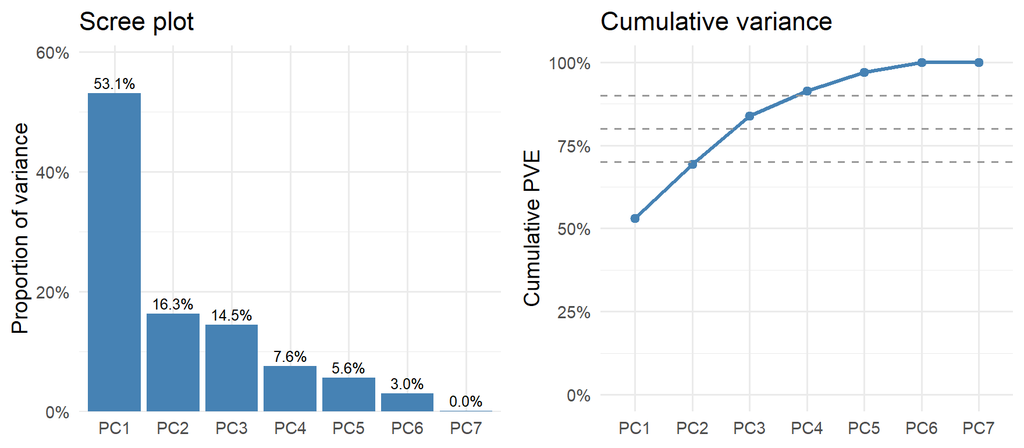

```r
p_scree <- ggplot(pve_df, aes(PC, PVE)) +
  geom_col(fill = "steelblue") +
  geom_text(aes(label = percent(PVE, accuracy = 0.1)),
            vjust = -0.4, size = 3) +
  scale_y_continuous(labels = percent_format(),
                     expand = expansion(mult = c(0, 0.15))) +
  labs(title = "Scree plot", x = NULL, y = "Proportion of variance")

p_cum <- ggplot(pve_df, aes(PC, cumulative, group = 1)) +
  geom_line(colour = "steelblue", linewidth = 1) +
  geom_point(colour = "steelblue", size = 2) +
  geom_hline(yintercept = c(0.7, 0.8, 0.9),
             linetype = "dashed", colour = "grey60") +
  scale_y_continuous(labels = percent_format(), limits = c(0, 1)) +
  labs(title = "Cumulative variance",
       x = NULL, y = "Cumulative PVE")

gridExtra::grid.arrange(p_scree, p_cum, nrow = 1)
```

```r
tibble(
  PC         = paste0("PC", seq_along(pr.out$sdev)),
  eigenvalue = pr.out$sdev^2,
  keep_kaiser = pr.out$sdev^2 > 1
)
```

| PC | eigenvalue | keep_kaiser |
| --- | --- | --- |
| PC1 | 3.714375498 | TRUE |
| PC2 | 1.138066225 | TRUE |
| PC3 | 1.013505432 | TRUE |
| PC4 | 0.531577934 | FALSE |
| PC5 | 0.392447068 | FALSE |
| PC6 | 0.207411019 | FALSE |
| PC7 | 0.002616824 | FALSE |

# 6. Loadings — what each PC actually means

```r
loadings <- as_tibble(pr.out$rotation, rownames = "feature")
loadings |> mutate(across(where(is.numeric), \(x) round(x, 2)))
```

| feature | PC1 | PC2 | PC3 | PC4 | PC5 | PC6 | PC7 |
| --- | --- | --- | --- | --- | --- | --- | --- |
| log_Recency | -0.35 | -0.35 | -0.03 | -0.87 | 0.07 | -0.02 | 0.00 |
| log_Frequency | 0.46 | 0.25 | -0.15 | -0.25 | 0.19 | -0.60 | -0.50 |
| log_Monetary | 0.48 | -0.28 | -0.06 | -0.06 | 0.24 | -0.25 | 0.75 |
| log_UniqueProducts | 0.42 | -0.09 | 0.14 | -0.21 | -0.86 | 0.07 | -0.01 |
| log_AvgOrderValue | 0.26 | -0.79 | 0.09 | 0.22 | 0.19 | 0.18 | -0.44 |
| AvgUnitPrice | -0.08 | -0.15 | -0.96 | 0.11 | -0.21 | 0.02 | 0.00 |
| TenureDays | 0.43 | 0.30 | -0.16 | -0.28 | 0.28 | 0.74 | -0.04 |

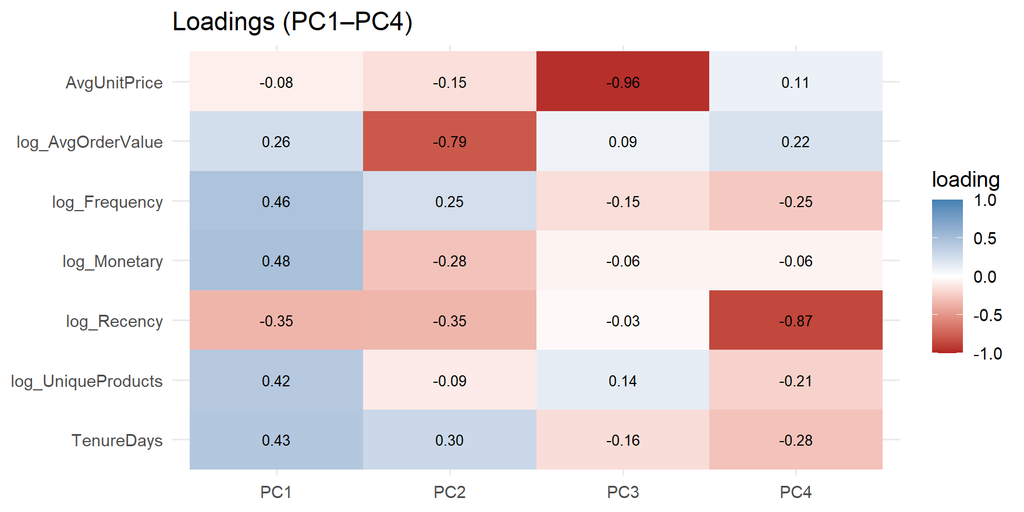

```r
loadings |>
  pivot_longer(-feature, names_to = "PC", values_to = "loading") |>
  filter(PC %in% paste0("PC", 1:4)) |>
  mutate(PC = factor(PC, levels = paste0("PC", 1:4))) |>
  ggplot(aes(PC, fct_rev(feature), fill = loading)) +
  geom_tile() +
  geom_text(aes(label = sprintf("%.2f", loading)), size = 3) +
  scale_fill_gradient2(low = "firebrick", mid = "white",
                       high = "steelblue", midpoint = 0,
                       limits = c(-1, 1)) +
  labs(title = "Loadings (PC1–PC4)", x = NULL, y = NULL)
```

# 7. PC scores — the new feature space

```r
scores <- as_tibble(pr.out$x) |>
  mutate(CustomerID = X$CustomerID, .before = 1) |>
  left_join(customer |> select(CustomerID, Monetary, Frequency,
                               Recency, Country, ReturnRate),
            by = "CustomerID")

head(scores)
```

| CustomerID | PC1 | PC2 | PC3 | PC4 | PC5 | PC6 | PC7 | Monetary | Frequency | Recency | Country | ReturnRate |
| --- | --- | --- | --- | --- | --- | --- | --- | --- | --- | --- | --- | --- |
| 12346 | 1.3980174 | -7.5967590 | 1.65612072 | 1.1027269 | 4.413507984 | 0.03108592 | -0.000231661 | 77183.60 | 1 | 326 | United Kingdom | 0.500 |
| 12347 | 3.3686184 | 0.2283065 | 0.05784925 | 0.9043135 | 0.325450246 | 0.58811354 | -0.010495414 | 4310.00 | 7 | 2 | Iceland | 0.000 |
| 12348 | 0.8450484 | 0.1619330 | 1.17999522 | -0.7837433 | 1.285703894 | 0.47009744 | 0.033631015 | 1437.24 | 4 | 75 | Finland | 0.000 |
| 12349 | 0.4173196 | -2.3812020 | -0.10153858 | 1.4545589 | -0.660812095 | 0.16312041 | -0.048190191 | 1457.55 | 1 | 19 | Italy | 0.000 |
| 12350 | -1.8772277 | -0.6700957 | 1.16329866 | -0.6286942 | 0.236678281 | -0.05352601 | -0.041408208 | 294.40 | 1 | 310 | Norway | 0.000 |
| 12352 | 1.2552178 | 0.7001810 | -0.91296856 | -0.5704532 | -0.008425634 | -0.09506090 | 0.016810624 | 1385.74 | 7 | 36 | Norway | 0.125 |

## 7a. PC1 vs PC2 scatter, coloured by spend

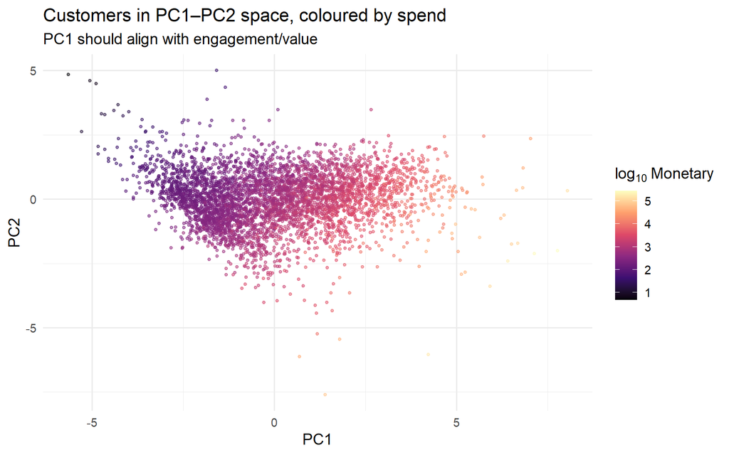

```r
ggplot(scores, aes(PC1, PC2, colour = log10(Monetary + 1))) +
  geom_point(alpha = 0.5, size = 0.8) +
  scale_colour_viridis_c(option = "magma",
                         name = expression(log[10]~Monetary)) +
  labs(title = "Customers in PC1–PC2 space, coloured by spend",
       subtitle = "PC1 should align with engagement/value")
```

## 7b. PC1 vs PC2 scatter, coloured by recency

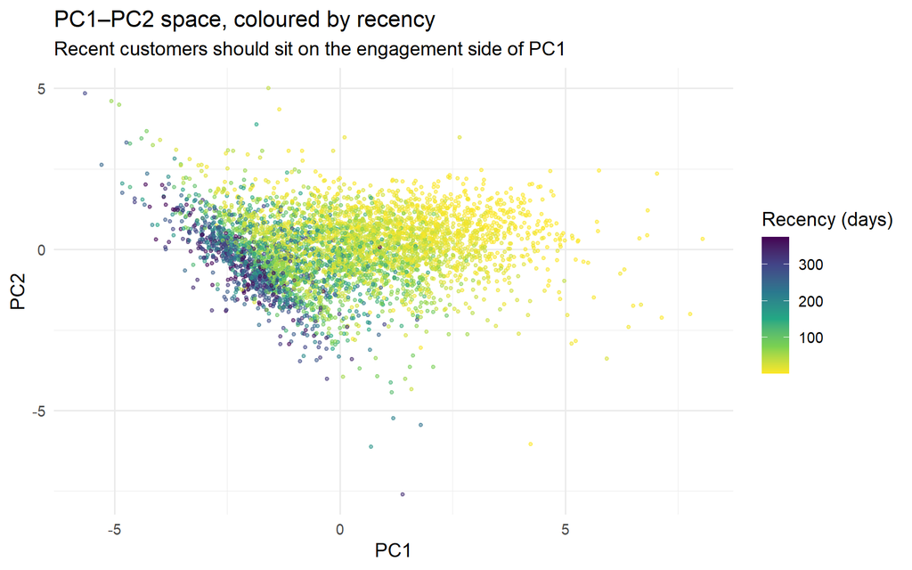

```r
ggplot(scores, aes(PC1, PC2, colour = Recency)) +
  geom_point(alpha = 0.5, size = 0.8) +
  scale_colour_viridis_c(option = "viridis", direction = -1,
                         name = "Recency (days)") +
  labs(title = "PC1–PC2 space, coloured by recency",
       subtitle = "Recent customers should sit on the engagement side of PC1")
```

## 7c. PC2 vs PC3, coloured by AvgUnitPrice

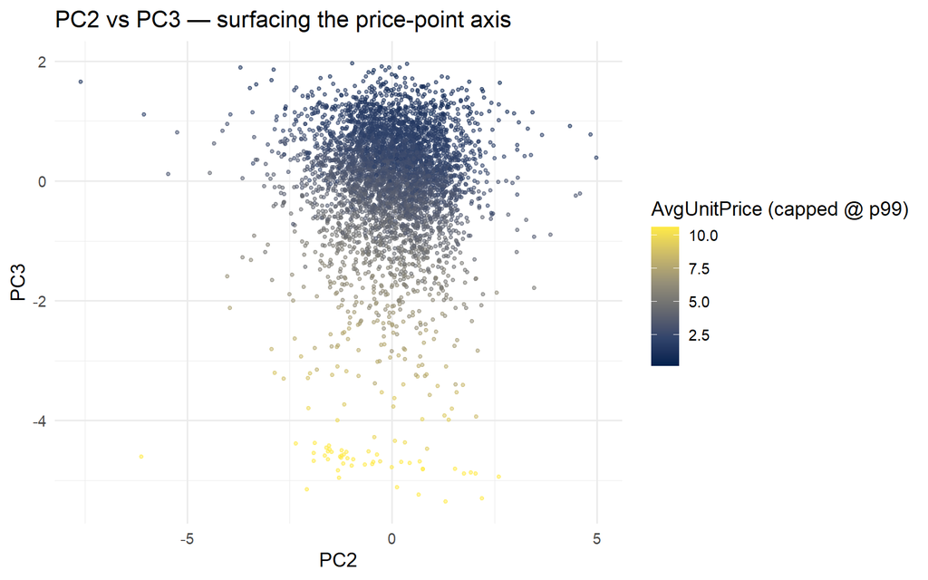

```r
ggplot(scores, aes(PC2, PC3,
                   colour = pmin(customer$AvgUnitPrice[match(CustomerID,
                                                             customer$CustomerID)],
                                 quantile(customer$AvgUnitPrice, 0.99,
                                          na.rm = TRUE)))) +
  geom_point(alpha = 0.5, size = 0.8) +
  scale_colour_viridis_c(option = "cividis",
                         name = "AvgUnitPrice (capped @ p99)") +
  labs(title = "PC2 vs PC3 — surfacing the price-point axis")
```

# 8. Biplot

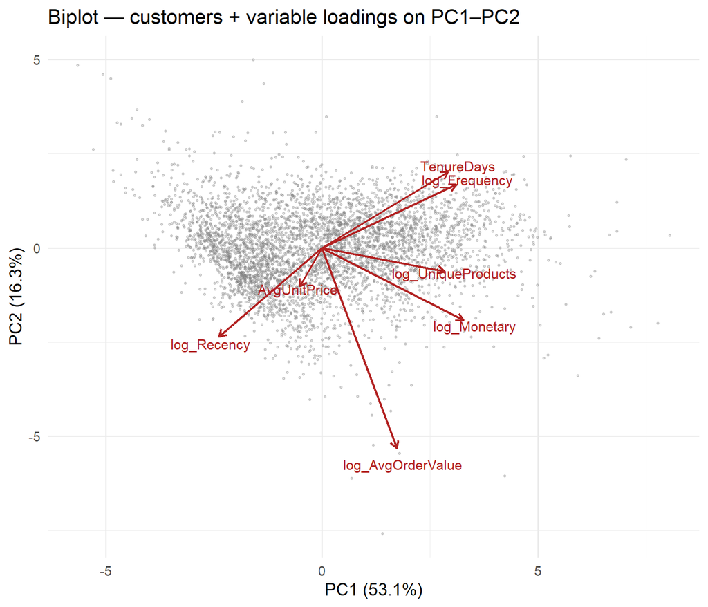

```r
arrow_scale <- with(pr.out,
                    min(max(abs(x[, 1])) / max(abs(rotation[, 1])),
                        max(abs(x[, 2])) / max(abs(rotation[, 2])))) * 0.7

arrows_df <- as_tibble(pr.out$rotation, rownames = "feature") |>
  mutate(PC1 = PC1 * arrow_scale,
         PC2 = PC2 * arrow_scale)

ggplot(scores, aes(PC1, PC2)) +
  geom_point(alpha = 0.25, size = 0.6, colour = "grey50") +
  geom_segment(data = arrows_df,
               aes(x = 0, y = 0, xend = PC1, yend = PC2),
               arrow = arrow(length = unit(0.2, "cm")),
               colour = "firebrick", linewidth = 0.7) +
  geom_text(data = arrows_df,
            aes(x = PC1 * 1.08, y = PC2 * 1.08, label = feature),
            colour = "firebrick", size = 3.5) +
  labs(title = "Biplot — customers + variable loadings on PC1–PC2",
       x = sprintf("PC1 (%s)", percent(pve[1], accuracy = 0.1)),
       y = sprintf("PC2 (%s)", percent(pve[2], accuracy = 0.1)))
```

# 9. Outlier check on PC1

The EDA Pareto curve suggested the top ~1% of customers might pull a disproportionate amount of variance. With log scaling that should be much tamer, but worth confirming on PC1.

```r
scores |>
  arrange(desc(PC1)) |>
  slice_head(n = 10) |>
  select(CustomerID, PC1, PC2, Monetary, Frequency, Recency, Country)
```

| CustomerID | PC1 | PC2 | Monetary | Frequency | Recency | Country |
| --- | --- | --- | --- | --- | --- | --- |
| 14911 | 8.047071 | 0.3248214 | 136161.83 | 198 | 1 | EIRE |
| 14646 | 7.772339 | -2.0101672 | 279138.02 | 72 | 2 | Netherlands |
| 18102 | 7.140339 | -2.1206914 | 259657.30 | 60 | 1 | United Kingdom |
| 12748 | 7.041259 | 2.3402199 | 31650.78 | 206 | 1 | United Kingdom |
| 17841 | 6.829754 | 1.2084907 | 40495.99 | 124 | 2 | United Kingdom |
| 15311 | 6.824751 | 0.4347397 | 60632.75 | 91 | 1 | United Kingdom |
| 14156 | 6.687506 | -1.7151842 | 116560.08 | 54 | 10 | EIRE |
| 13089 | 6.648899 | 0.3382603 | 58762.08 | 97 | 3 | United Kingdom |
| 17511 | 6.514556 | -1.7566448 | 91062.38 | 31 | 3 | United Kingdom |
| 17450 | 6.411752 | -2.4070189 | 194390.79 | 46 | 8 | United Kingdom |

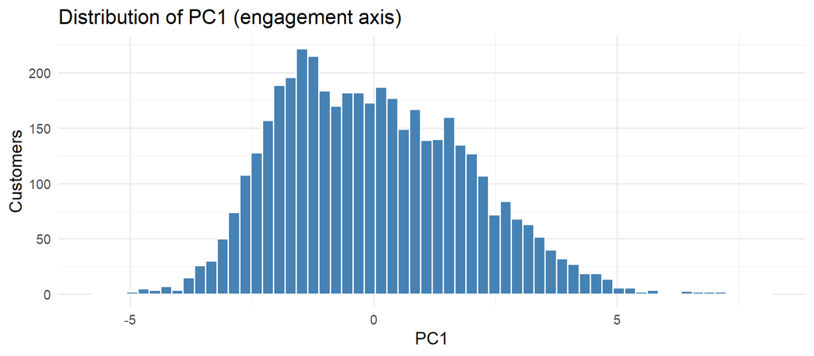

```r
ggplot(scores, aes(PC1)) +
  geom_histogram(bins = 60, fill = "steelblue", colour = "white") +
  labs(title = "Distribution of PC1 (engagement axis)",
       x = "PC1", y = "Customers")
```

PC1 looks roughly symmetric and unimodal so we’re fine to cluster on it directly.

# 10. Save PC scores for the clustering step

We keep the first **k** PCs where `k` is the smallest number that crosses 80% cumulative variance — defensible under both the elbow heuristic and the variance-threshold heuristic. Adjust `k` here if the scree suggests otherwise.

```r
k <- which(cumsum(pve) >= 0.80)[1]
k
```

```
## [1] 3
```

```r
scores_out <- scores |>
  select(CustomerID, all_of(paste0("PC", 1:k)))

write_csv(scores_out, "../data/customer_pc_scores.csv")

list(
  components_kept = k,
  variance_kept   = percent(sum(pve[1:k]), accuracy = 0.1),
  customers       = nrow(scores_out)
)
```

```
## $components_kept
## [1] 3
##
## $variance_kept
## [1] "83.8%"
##
## $customers
## [1] 4334
```